# Prosper Loan: Exploratory Data Analysis by Kyle Wilbert

This report explores a dataset of about 113,937 loans made by peer-to-peer lender Prosper between 2005 and 2014.

# Univariate Plots Section

```
## [1] 113937     16
```

```
## 'data.frame':    113937 obs. of  16 variables:
##  $ LoanStatus               : Factor w/ 12 levels "Cancelled","Chargedoff",..: 3 4 3 4 4 4 4 4 4 4 ...
##  $ LoanOriginationDate      : Date, format: "2007-09-12" "2014-03-03" ...
##  $ LoanOriginationQuarter   : Factor w/ 33 levels "Q1 2006","Q1 2007",..: 18 8 2 32 24 33 16 16 33 33 ...
##  $ LoanOriginalAmount       : int  9425 10000 3001 10000 15000 15000 3000 10000 10000 10000 ...
##  $ Term                     : int  36 36 36 36 36 60 36 36 36 36 ...
##  $ ClosedDate               : Factor w/ 2803 levels "","2005-11-25 00:00:00",..: 1138 1 1263 1 1 1 1 1 1 1 ...
##  $ LenderYield              : num  0.138 0.082 0.24 0.0874 0.1985 ...
##  $ LoanCurrentDaysDelinquent: int  0 0 0 0 0 0 0 0 0 0 ...
##  $ RevolvingCreditBalance   : num  0 3989 NA 1444 6193 ...
##  $ BorrowerRate             : num  0.158 0.092 0.275 0.0974 0.2085 ...
##  $ ProsperRating..Alpha.    : Factor w/ 8 levels "","A","AA","B",..: 1 2 1 2 6 4 7 5 3 3 ...
##  $ BorrowerState            : Factor w/ 52 levels "","AK","AL","AR",..: 7 7 12 12 25 34 18 6 16 16 ...
##  $ EmploymentStatus         : Factor w/ 9 levels "","Employed",..: 9 2 4 2 2 2 2 2 2 2 ...
##  $ EmploymentStatusDuration : int  2 44 NA 113 44 82 172 103 269 269 ...
##  $ DebtToIncomeRatio        : num  0.17 0.18 0.06 0.15 0.26 0.36 0.27 0.24 0.25 0.25 ...
##  $ IncomeRange              : Factor w/ 8 levels "$0","$1-24,999",..: 4 5 7 4 3 3 4 4 4 4 ...
```

```
##                  LoanStatus    LoanOriginationDate  LoanOriginationQuarter
##  Current              :56576   Min.   :2005-11-15   Q4 2013:14450
##  Completed            :38074   1st Qu.:2008-10-02   Q1 2014:12172
##  Chargedoff           :11992   Median :2012-06-26   Q3 2013: 9180
##  Defaulted            : 5018   Mean   :2011-07-21   Q2 2013: 7099
##  Past Due (1-15 days) :  806   3rd Qu.:2013-09-18   Q3 2012: 5632
##  Past Due (31-60 days):  363   Max.   :2014-03-12   Q2 2012: 5061
##  (Other)              : 1108                        (Other):60343
##  LoanOriginalAmount      Term                     ClosedDate
##  Min.   : 1000      Min.   :12.00                      :58848
##  1st Qu.: 4000      1st Qu.:36.00   2014-03-04 00:00:00:  105
##  Median : 6500      Median :36.00   2014-02-19 00:00:00:  100
##  Mean   : 8337      Mean   :40.83   2014-02-11 00:00:00:   92
##  3rd Qu.:12000      3rd Qu.:36.00   2012-10-30 00:00:00:   81
##  Max.   :35000      Max.   :60.00   2013-02-26 00:00:00:   78
##                                     (Other)            :54633
##   LenderYield      LoanCurrentDaysDelinquent RevolvingCreditBalance
##  Min.   :-0.0100   Min.   :   0.0            Min.   :      0
##  1st Qu.: 0.1242   1st Qu.:   0.0            1st Qu.:   3121
##  Median : 0.1730   Median :   0.0            Median :   8549
##  Mean   : 0.1827   Mean   : 152.8            Mean   :  17599
##  3rd Qu.: 0.2400   3rd Qu.:   0.0            3rd Qu.:  19521
##  Max.   : 0.4925   Max.   :2704.0            Max.   :1435667
##                                              NA's   :7604
##   BorrowerRate    ProsperRating..Alpha. BorrowerState
##  Min.   :0.0000          :29084         CA     :14717
##  1st Qu.:0.1340   C      :18345         TX     : 6842
##  Median :0.1840   B      :15581         NY     : 6729
##  Mean   :0.1928   A      :14551         FL     : 6720
##  3rd Qu.:0.2500   D      :14274         IL     : 5921
##  Max.   :0.4975   E      : 9795                : 5515
##                   (Other):12307         (Other):67493
##       EmploymentStatus EmploymentStatusDuration DebtToIncomeRatio
##  Employed     :67322   Min.   :  0.00           Min.   : 0.000
##  Full-time    :26355   1st Qu.: 26.00           1st Qu.: 0.140
##  Self-employed: 6134   Median : 67.00           Median : 0.220
##  Not available: 5347   Mean   : 96.07           Mean   : 0.276
##  Other        : 3806   3rd Qu.:137.00           3rd Qu.: 0.320
##               : 2255   Max.   :755.00           Max.   :10.010
##  (Other)      : 2718   NA's   :7625             NA's   :8554
##          IncomeRange
##  $25,000-49,999:32192
##  $50,000-74,999:31050
##  $100,000+     :17337
##  $75,000-99,999:16916
##  Not displayed : 7741
##  $1-24,999     : 7274
##  (Other)       : 1427
```

```
##              Cancelled             Chargedoff              Completed
##                      5                  11992                  38074
##                Current              Defaulted FinalPaymentInProgress
##                  56576                   5018                    205
##   Past Due (>120 days)   Past Due (1-15 days)  Past Due (16-30 days)
##                     16                    806                    265
##  Past Due (31-60 days)  Past Due (61-90 days) Past Due (91-120 days)
##                    363                    313                    304
```

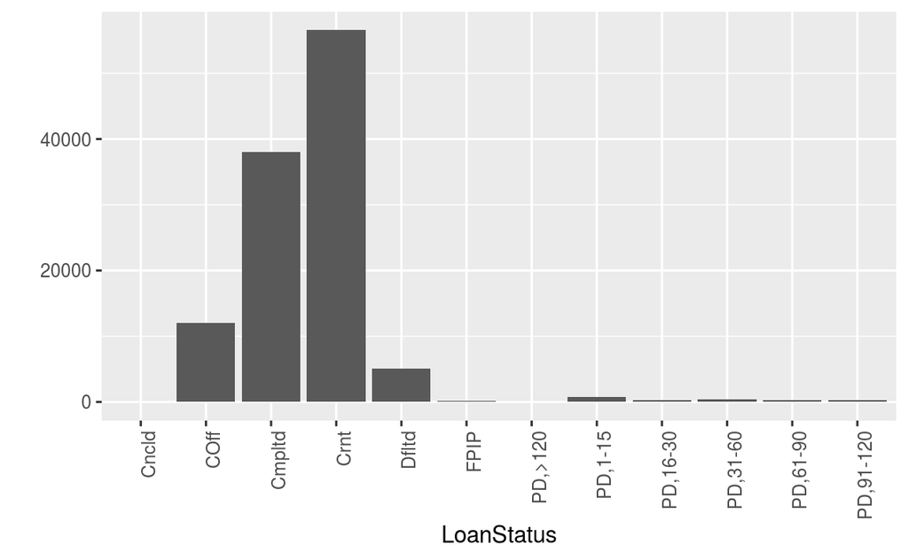

Will need to define Cancelled, Charged-Off, and Defaulted, to accurately analyze loss. Seems like a fairly large amount of chargeoffs (A charge-off or chargeoff is the declaration by a creditor (usually a credit card account) that an amount of debt is unlikely to be collected. This occurs when a consumer becomes severely delinquent on a debt. Traditionally, creditors will make this declaration at the point of six months without payment. A charge-off is a form of write-off.  
Source: Wikipedia https://en.wikipedia.org/wiki/Charge-off)

```
##  [1] "Q1 2006" "Q1 2007" "Q1 2008" "Q1 2010" "Q1 2011" "Q1 2012" "Q1 2013"
##  [8] "Q1 2014" "Q2 2006" "Q2 2007" "Q2 2008" "Q2 2009" "Q2 2010" "Q2 2011"
## [15] "Q2 2012" "Q2 2013" "Q3 2006" "Q3 2007" "Q3 2008" "Q3 2009" "Q3 2010"
## [22] "Q3 2011" "Q3 2012" "Q3 2013" "Q4 2005" "Q4 2006" "Q4 2007" "Q4 2008"
## [29] "Q4 2009" "Q4 2010" "Q4 2011" "Q4 2012" "Q4 2013"
```

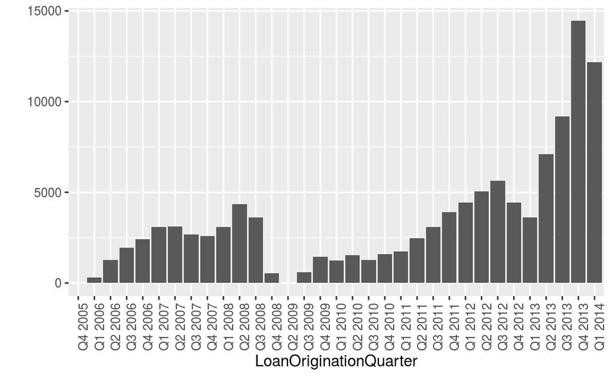

```
## # A tibble: 33 x 2
##    LoanOriginationQuarter     n
##    <fct>                  <int>
##  1 Q4 2005                   22
##  2 Q1 2006                  315
##  3 Q2 2006                 1254
##  4 Q3 2006                 1934
##  5 Q4 2006                 2403
##  6 Q1 2007                 3079
##  7 Q2 2007                 3118
##  8 Q3 2007                 2671
##  9 Q4 2007                 2592
## 10 Q1 2008                 3074
## # ... with 23 more rows
```

Q1 2009 is missing and Q2 2009 is smaller than Q4 2005 when it appears loans starte to be made originally.  
Source: https://www.lendacademy.com/prosper-review/

```
##    Min. 1st Qu.  Median    Mean 3rd Qu.    Max.
##    1000    4000    6500    8337   12000   35000
```

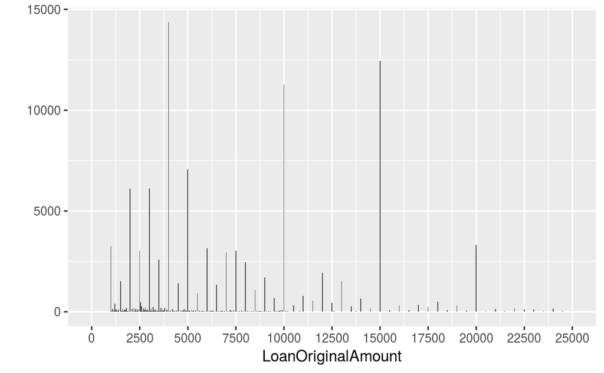

Showing the LoanOriginalAmount width a “skinny” binwidth of 50 reveals that most loans are originated with a round number ending in 5 or 0, as indicated by the spikes.

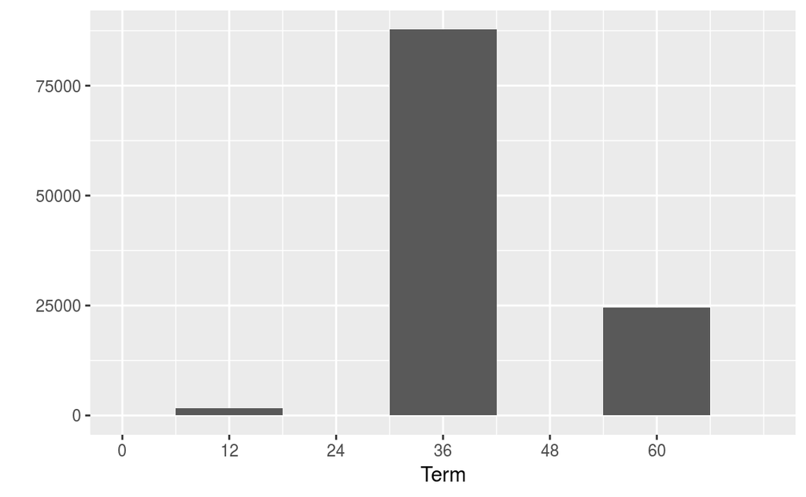

The most popular loan term is 36 months (3 years) followed by 6o months (5 years).

```
##    Min. 1st Qu.  Median    Mean 3rd Qu.    Max.
##     0.0     0.0     0.0   152.8     0.0  2704.0
```

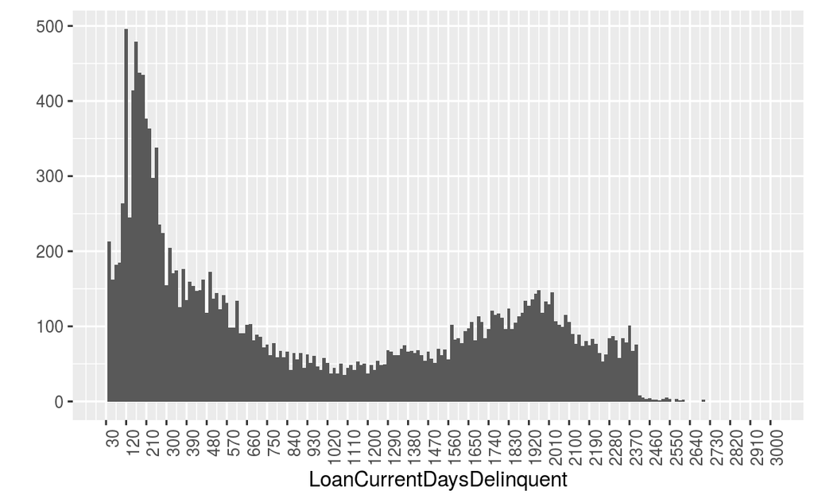

```
##    Min. 1st Qu.  Median    Mean 3rd Qu.    Max.    NA's
##       0    3121    8549   17599   19521 1435667    7604
```

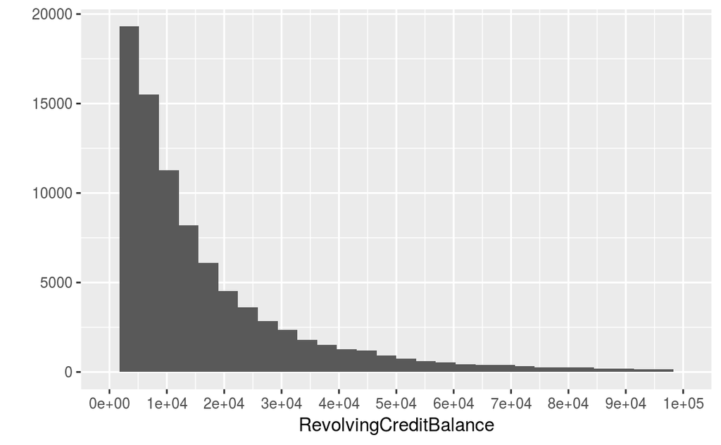

```
##    Min. 1st Qu.  Median    Mean 3rd Qu.    Max.
##  0.0000  0.1340  0.1840  0.1928  0.2500  0.4975
```

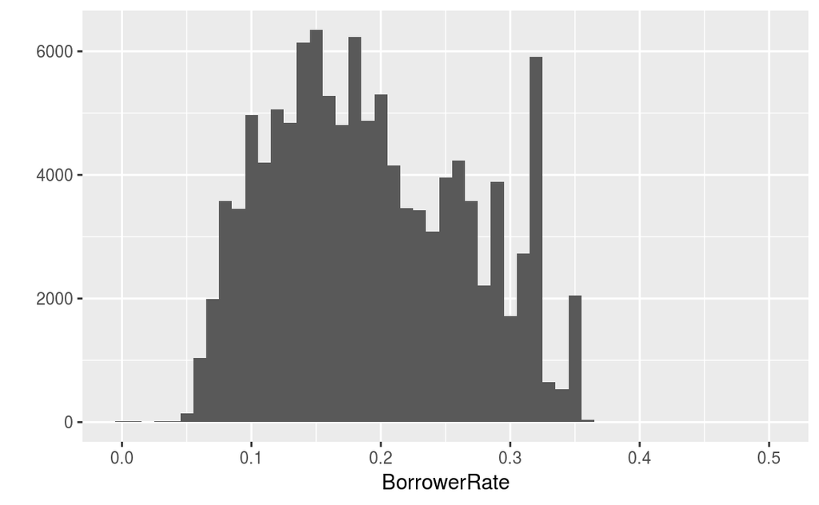

There is somewhat of a binomial distribution - the first between 0.15 and the other around 0.32. Correlated with DebttoIncome ratio?

```
##          AK    AL    AR    AZ    CA    CO    CT    DC    DE    FL    GA
##  5515   200  1679   855  1901 14717  2210  1627   382   300  6720  5008
##    HI    IA    ID    IL    IN    KS    KY    LA    MA    MD    ME    MI
##   409   186   599  5921  2078  1062   983   954  2242  2821   101  3593
##    MN    MO    MS    MT    NC    ND    NE    NH    NJ    NM    NV    NY
##  2318  2615   787   330  3084    52   674   551  3097   472  1090  6729
##    OH    OK    OR    PA    RI    SC    SD    TN    TX    UT    VA    VT
##  4197   971  1817  2972   435  1122   189  1737  6842   877  3278   207
##    WA    WI    WV    WY
##  3048  1842   391   150
```

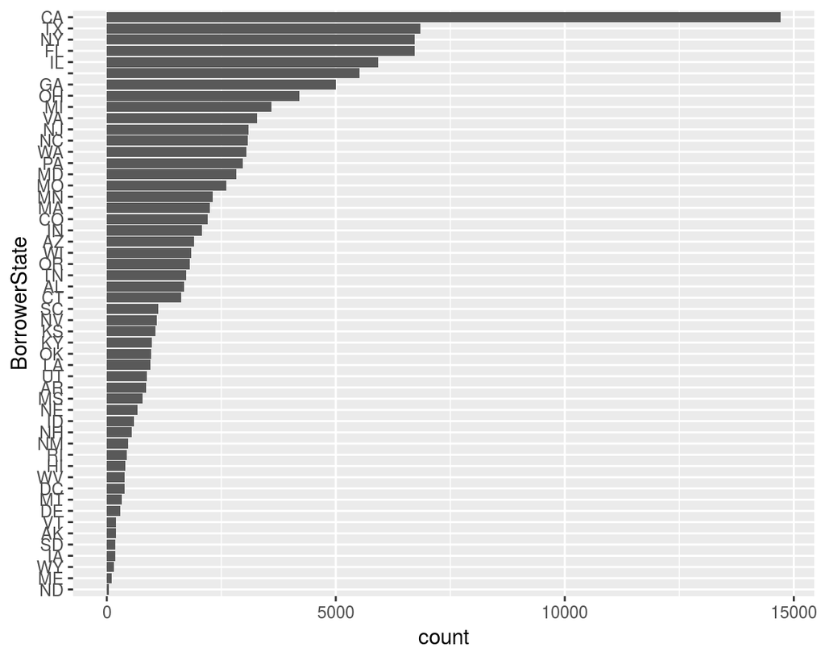

The top 5 states originating loans were California, Texas, New York, Florida, and Illinois. These states have the largest cities and the largest markets. Also, I’d imagine Prosper targeting these markets with marketing campaigns.

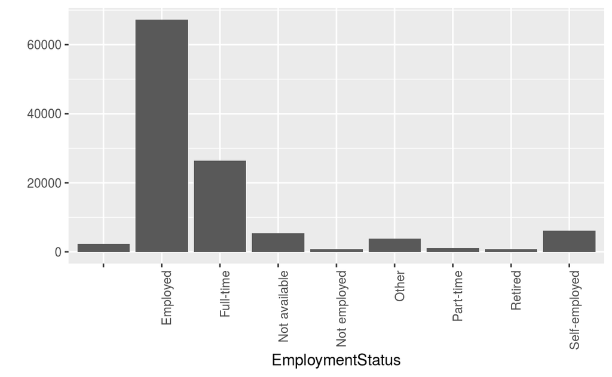

The EmploymentStatus variable is problematic. It does not appear that Full-Time, Self-Employed, and Part-Time, are a part of the Employed number. Rather than being subcategories they were originally coded as separate categories. As-is, it’s not a very useful variable for measuring risk in this analysis.

```
##    Min. 1st Qu.  Median    Mean 3rd Qu.    Max.    NA's
##    0.00   26.00   67.00   96.07  137.00  755.00    7625
```

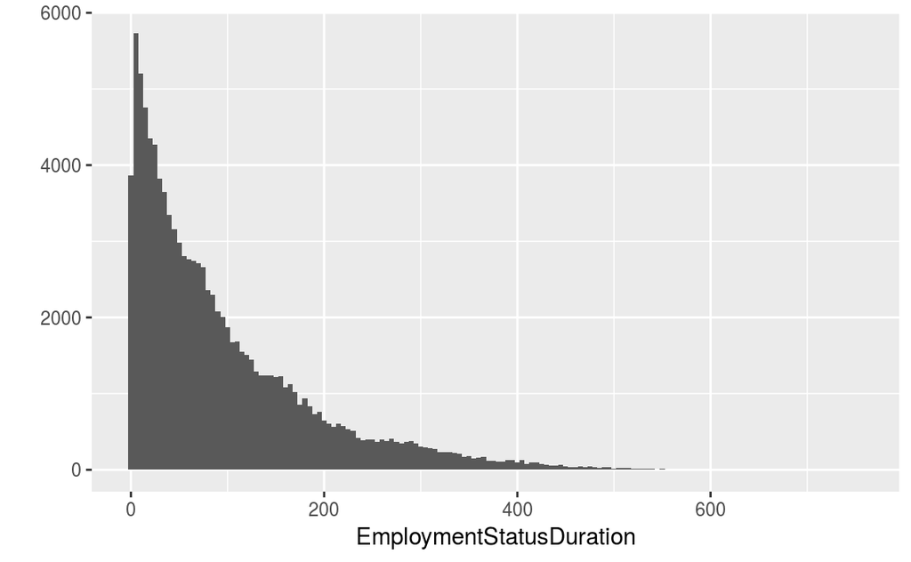

This is an odd variable too, as it could apply to employment or unemployment. So we need to look at this variable with EmploymentStatus for this to be useful.

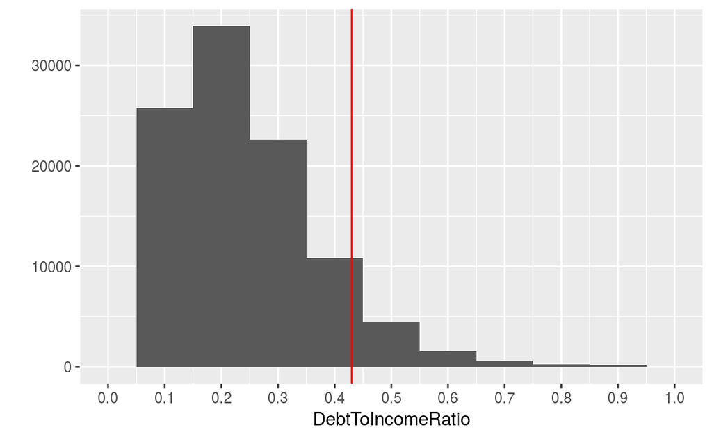

According to the CFBP, 43% is the highest debt-to-income ratio where borrowers can still qualify for a mortgage. it appears the bulk of borrowers are below that ratio (red line above). Source: https://www.consumerfinance.gov/ask-cfpb/what-is-a-debt-to-income-ratio-why-is-the-43-debt-to-income-ratio-important-en-1791/

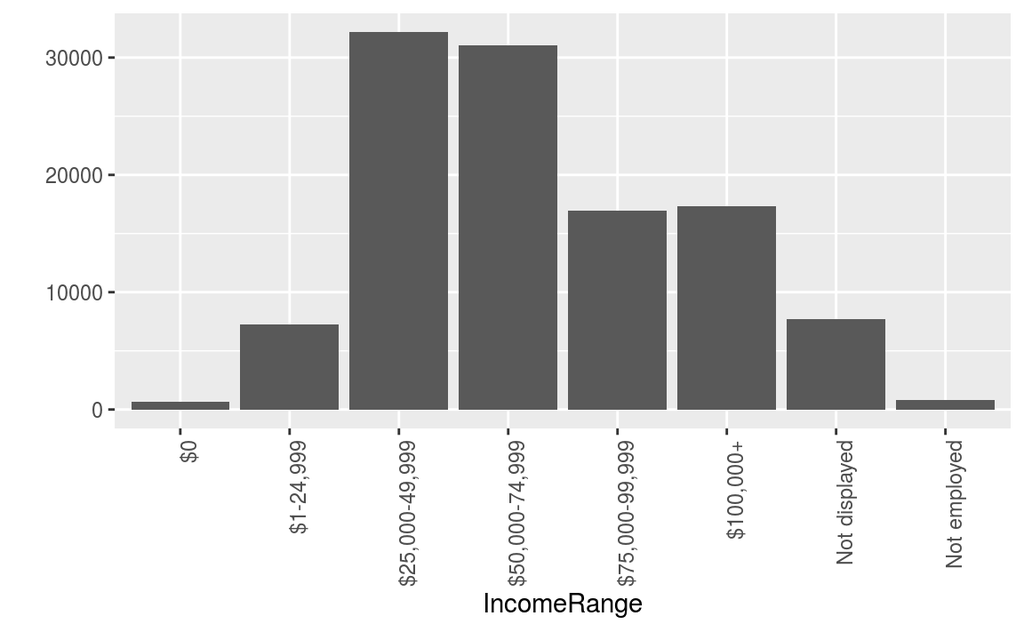

The data for income range appears to be a more accurate measure of employment and income than the EmploymentStatus variable.

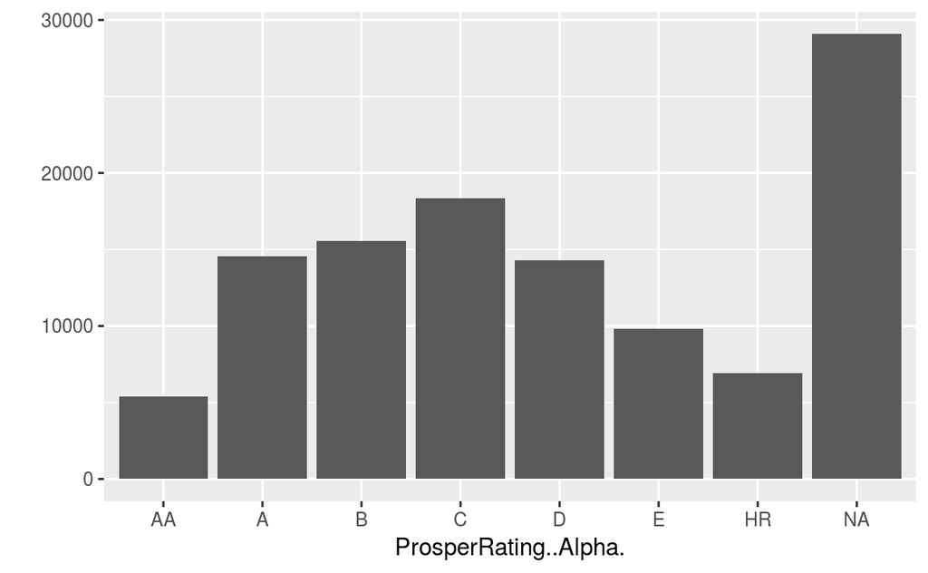

29,084 are missing Alpha ratings.

# Univariate Analysis

### What is the structure of your dataset?

There are 113,937 loans in the modified data set with 16 variables.

Anomalies - ProsperRating..Alpha is missing 29,084 values. Need to confirm that they are the same observations - IncomeRange has both $0, not employed, and not displayed factors. What’s the difference between $0 and not employed? I suppose if you are collecting unemployment, your income would not be zero but you would be not employed. But what about $0 income? - EmploymentStatus is a really messy, unhelpful variable. The counts for Full-Time, Part-Time, and Self-Employed are separate from the larger Employed category. - EmploymentStatusDuration is equally as unhelpful because it relies on EmploymentStatus. The duration can either be employed/unemployed (or any of its subcategories).

### What is/are the main feature(s) of interest in your dataset?

I’m mostly curious about what distinguishes a healthy loan to an unhealthy loan. To that end, I will look at LoanStatus, LoanOriginalAmount, the Prosper Ratings, BorrowerState, DebtToIncomeRatio, and IncomeRange.

### What other features in the dataset do you think will help support your

investigation into your feature(s) of interest? see above

### Did you create any new variables from existing variables in the dataset?

I created Loan OriginationQtr to do some time series analysis

### Of the features you investigated, were there any unusual distributions?

Did you perform any operations on the data to tidy, adjust, or change the form  
of the data? If so, why did you do this?

- both RevolvingCreditBalance and IncomeToDebtRatio have right-skewed distributions. They look exponential.
- otherwise, I tried using some tranforms on certain measures but they didn’t apppear to transform the data much.

# Bivariate Plots Section

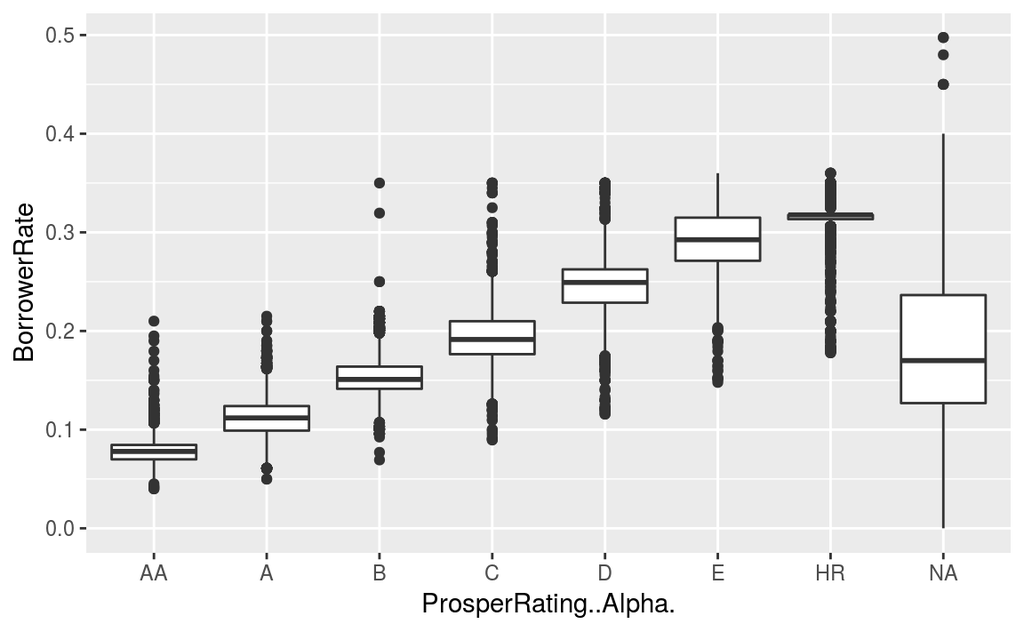

- The borrowers without a ProsperRating have a wide distribution compared to the borrowers with a rating - perhaps that’s why Prosper developed a rating.

- There appears to be a positive linear between the best ratings (from best to worst, AA to HR) and lower interest rates.

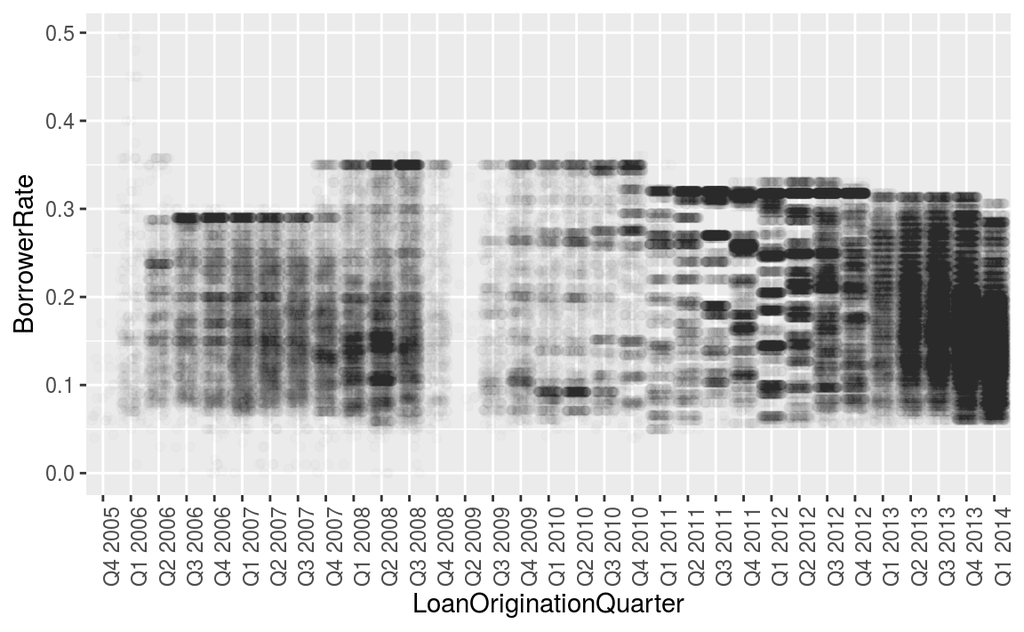

This shows an interesting picture of the business - pre-2009, there were fewer distinct borrower rates. Prior to the gap quarter/reorganization, the BorrowerRate widened. After the gap, there remained some high rate loans, but it appears they stopped doing higher rate loans in 2012. Most recently in 2014, you can see that they now use finer degrees of interest rates, likely based on their proprietary credit scoring models. Source: http://archive.fortune.com/2009/04/28/technology/hempel_prosper.fortune/index.htm

```
##    Min. 1st Qu.  Median    Mean 3rd Qu.    Max.    NA's
##   0.000   0.140   0.220   0.276   0.320  10.010    8554
```

```
## [1] 0.18
```

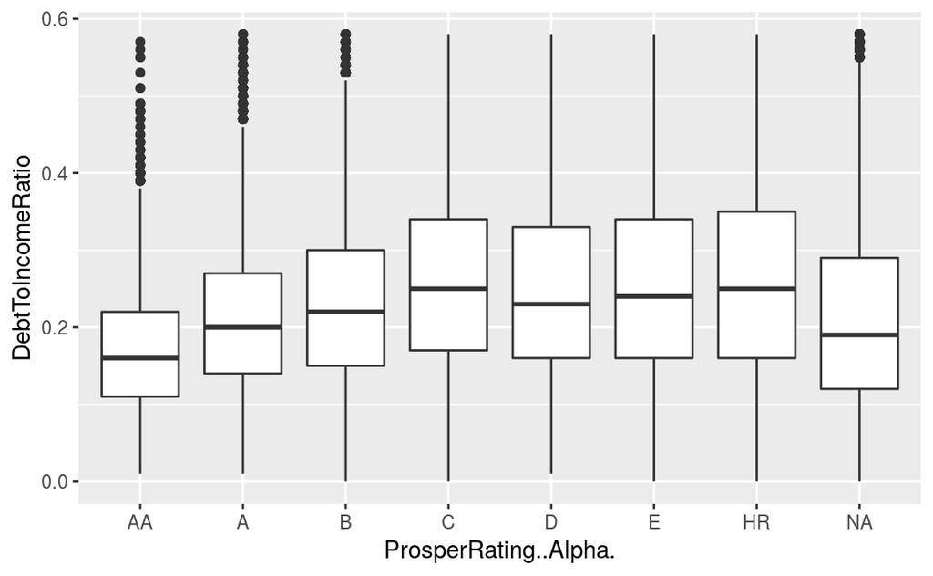

I removed any outliers in the DebtToIncomeRatio ((0.32) + 1.5(0.18)). From AA to C we see rising DebtToIncomeRatio as the Prosper Rating falls in quality. Past the C rating the trend disappears. There does appear to be a normal distribution of borrowers within each Prosper Rating, by Debt to Income ratio.

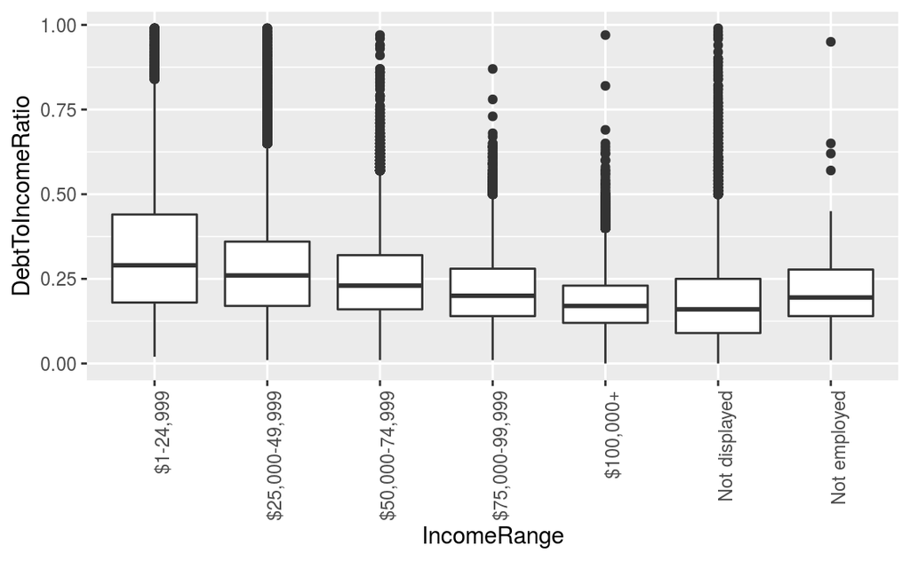

As you might expect, there is a relationship between DebtToIncomeRatio and IncomeRange. As income rises, the ratio drops.

```
## loans2$BorrowerState: ND
## [1] 52
## --------------------------------------------------------
## loans2$BorrowerState: ME
## [1] 101
## --------------------------------------------------------
## loans2$BorrowerState: WY
## [1] 150
## --------------------------------------------------------
## loans2$BorrowerState: IA
## [1] 186
## --------------------------------------------------------
## loans2$BorrowerState: SD
## [1] 189
## --------------------------------------------------------
## loans2$BorrowerState: AK
## [1] 200
## --------------------------------------------------------
## loans2$BorrowerState: VT
## [1] 207
## --------------------------------------------------------
## loans2$BorrowerState: DE
## [1] 300
## --------------------------------------------------------
## loans2$BorrowerState: MT
## [1] 330
## --------------------------------------------------------
## loans2$BorrowerState: DC
## [1] 382
## --------------------------------------------------------
## loans2$BorrowerState: WV
## [1] 391
## --------------------------------------------------------
## loans2$BorrowerState: HI
## [1] 409
## --------------------------------------------------------
## loans2$BorrowerState: RI
## [1] 435
## --------------------------------------------------------
## loans2$BorrowerState: NM
```

[output cut: 100 more lines]

```
## --------------------------------------------------------
## loans2$BorrowerState: IL
## [1] 5921
## --------------------------------------------------------
## loans2$BorrowerState: FL
## [1] 6720
## --------------------------------------------------------
## loans2$BorrowerState: NY
## [1] 6729
## --------------------------------------------------------
## loans2$BorrowerState: TX
## [1] 6842
## --------------------------------------------------------
## loans2$BorrowerState: CA
## [1] 14717
```

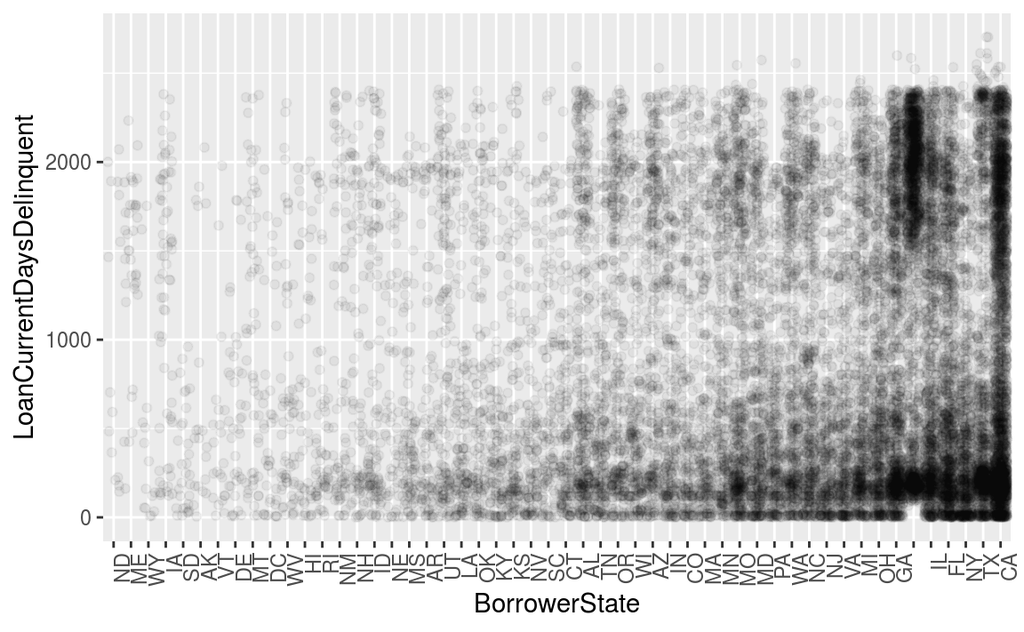

There are a surprising number of delinquincies without information about origination state (rank:6). It looks like Prosper wasn’t collecting enough data or lost some data at some point.

```
## loans2$EmploymentStatus:
##    Min. 1st Qu.  Median    Mean 3rd Qu.    Max.    NA's
##      NA      NA      NA     NaN      NA      NA    2255
## --------------------------------------------------------
## loans2$EmploymentStatus: Employed
##    Min. 1st Qu.  Median    Mean 3rd Qu.    Max.    NA's
##     0.0    31.0    75.0   103.5   150.0   745.0       1
## --------------------------------------------------------
## loans2$EmploymentStatus: Full-time
##    Min. 1st Qu.  Median    Mean 3rd Qu.    Max.    NA's
##    0.00   20.00   51.00   79.83  110.00  623.00      13
## --------------------------------------------------------
## loans2$EmploymentStatus: Not available
##    Min. 1st Qu.  Median    Mean 3rd Qu.    Max.    NA's
##      NA      NA      NA     NaN      NA      NA    5347
## --------------------------------------------------------
## loans2$EmploymentStatus: Not employed
##    Min. 1st Qu.  Median    Mean 3rd Qu.    Max.    NA's
##    0.00    3.00   13.00   36.08   41.00  359.00       1
## --------------------------------------------------------
## loans2$EmploymentStatus: Other
##    Min. 1st Qu.  Median    Mean 3rd Qu.    Max.    NA's
##     0.0     8.0    52.0   102.2   132.0   755.0       6
## --------------------------------------------------------
## loans2$EmploymentStatus: Part-time
##    Min. 1st Qu.  Median    Mean 3rd Qu.    Max.
##    0.00    8.00   22.00   37.37   50.00  552.00
## --------------------------------------------------------
## loans2$EmploymentStatus: Retired
##    Min. 1st Qu.  Median    Mean 3rd Qu.    Max.
##     0.0    42.0    81.0   100.4   135.5   584.0
## --------------------------------------------------------
## loans2$EmploymentStatus: Self-employed
##    Min. 1st Qu.  Median    Mean 3rd Qu.    Max.    NA's
##    0.00   26.00   68.00   98.79  138.00  649.00       2
```

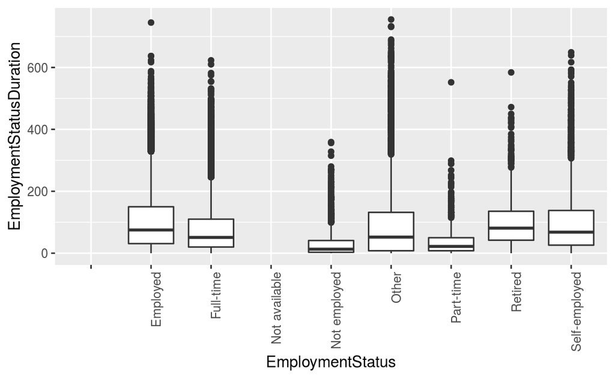

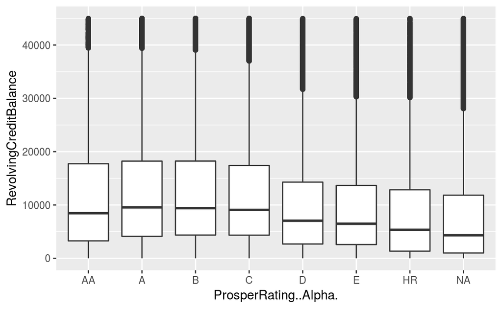

It appears that RevolvingCreditBalance also factors into the Prosper Rating. As ratings decrease, the median revolving credit also decreases. Also note that those with an A rating have a slightly higher median than those with a AA rating.

# Bivariate Analysis

### Talk about some of the relationships you observed in this part of the

investigation. How did the feature(s) of interest vary with other features in  
the dataset?

Covariation - RevolvingCreditBalance, DebtToIncomeRatio, and BorrowerRate all move parallel to the Prosper Rating, with BorrowerRate showing the most covariation

### Did you observe any interesting relationships between the other features

(not the main feature(s) of interest)?

- shocking number of delinquencies without a BorrowerState recorded
- EmploymentStatus and EmploymentStatusDuration does not appear to show strong pattern

### What was the strongest relationship you found?

The strongest relationship was between BorrowerRate and ProsperRating

# Multivariate Plots Section

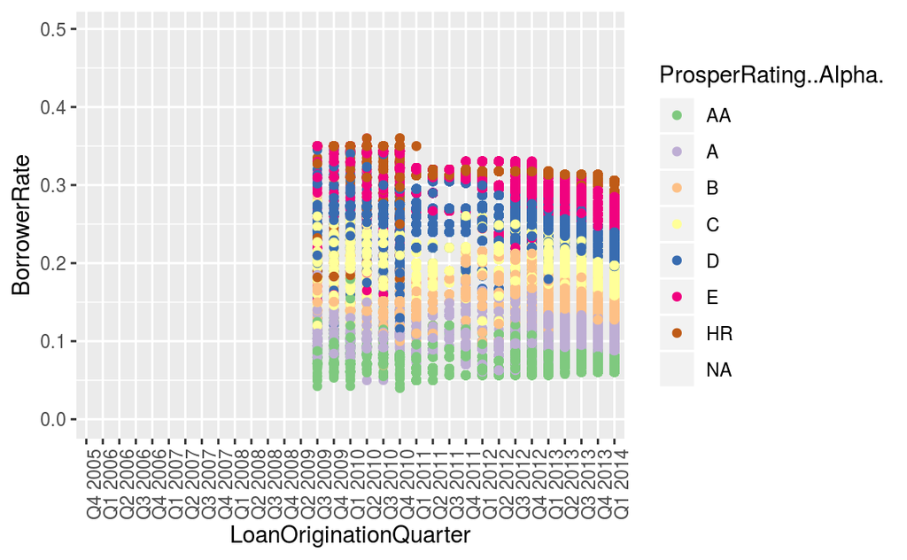

The colors make clear here that pre-2009, there was no Prosper Rating, hence no color. After the business rules reset in 2009, we start to see the implementation of Prosper Ratings. We also see that the better ratings receive more favorable borrowing rates.

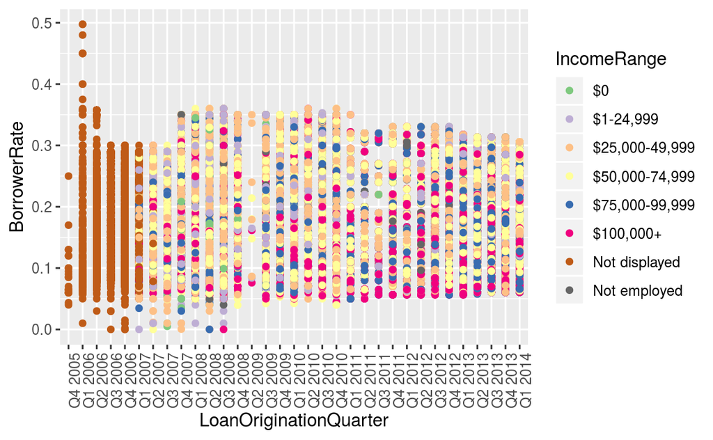

Not much of a pattern here - income is not a strong determinant of borrower rate. There is some overplotting that I wasn’t able to remove without also removing the color legend.

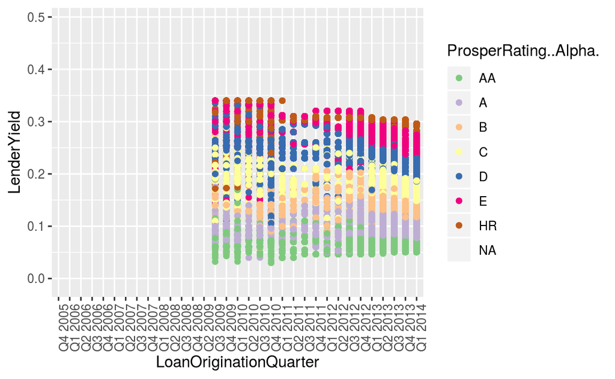

Interesting - this chart looks very similar to the first multivariate chart we looked at. The difference, however, is that this shows the LenderYield is higher when they the investor funded riskier loans (based on Prosper Rating). Basically, there is an inverse relationship between a borrower’s Prosper Rating and the lender’s yield. High risk, high reward and vice versa.

# Multivariate Analysis

### Talk about some of the relationships you observed in this part of the

investigation. Were there features that strengthened each other in terms of  
looking at your feature(s) of interest?

- The ProsperRating helps borrowers secure a lower rate while it is a signal to lender about which loans will be safe or risky. Safe loans have lower yields than more risky loans.

Borrowers benefit from a higher quality rating while lenders see more money from lower quality ratings.

- Income is not a strong factor in determining borrower rate. ### Were there any interesting or surprising interactions between features? It’s not very surprising when I think about it but seeing the similarity between charts for borrower rate colored with Rating versus lender yield colored with Rating was amusing.

# Final Plots and Summary

### Plot One

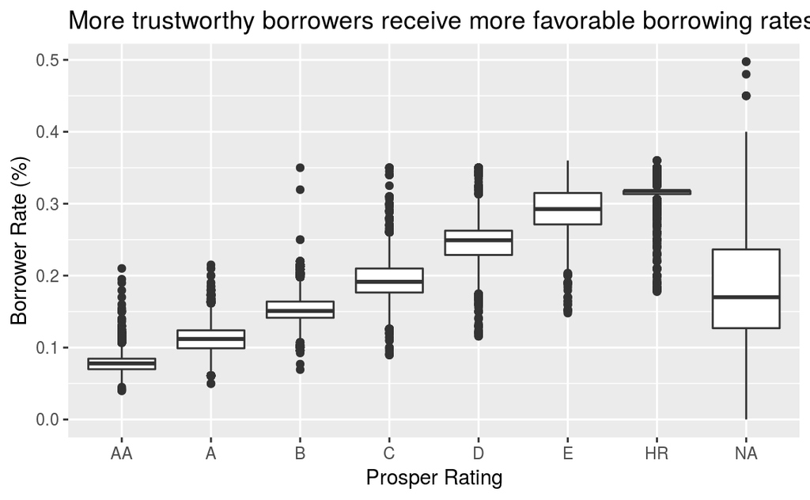

### Description One

Post-2009, Prosper tightened up its lending rules and established its own rating system. The chart above shows clearly that borrowers with better ratings (AA=best, HR=worst) receive more favorable borrowing rates. We will see this more clearly in the next plot.

### Plot Two

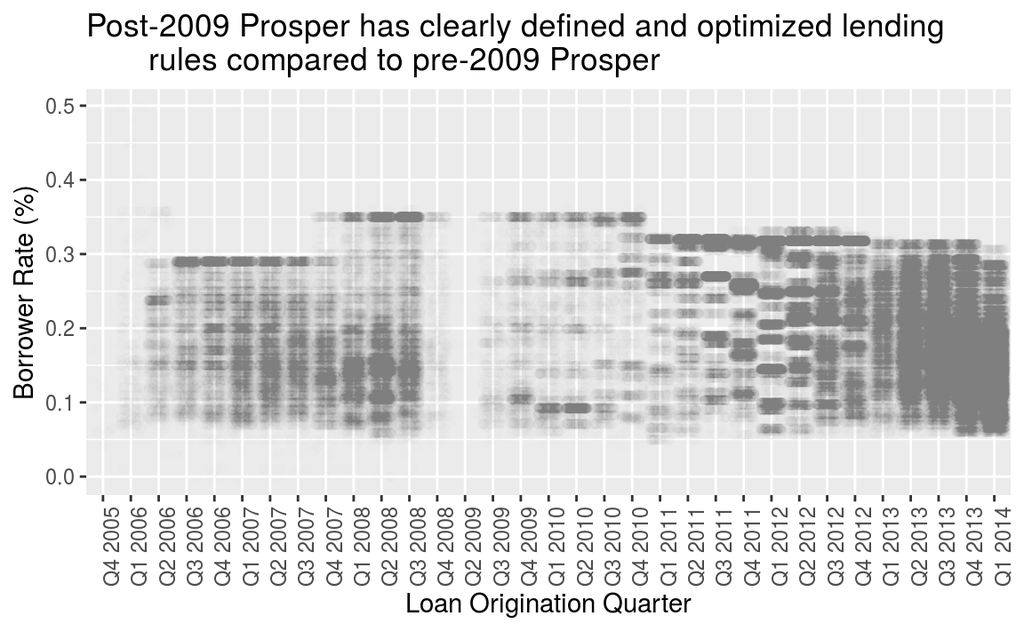

### Description Two

Pre-2009 we can see that many loans had high borrower rates indicating that these borrowers were quite risky. Post-2009, we see the distribution of rates begin to change and more loans have lower rates and the rates are more defined. This indicates that it instituted strong lending rules in order to establish a more stable portfolio.

### Plot Three

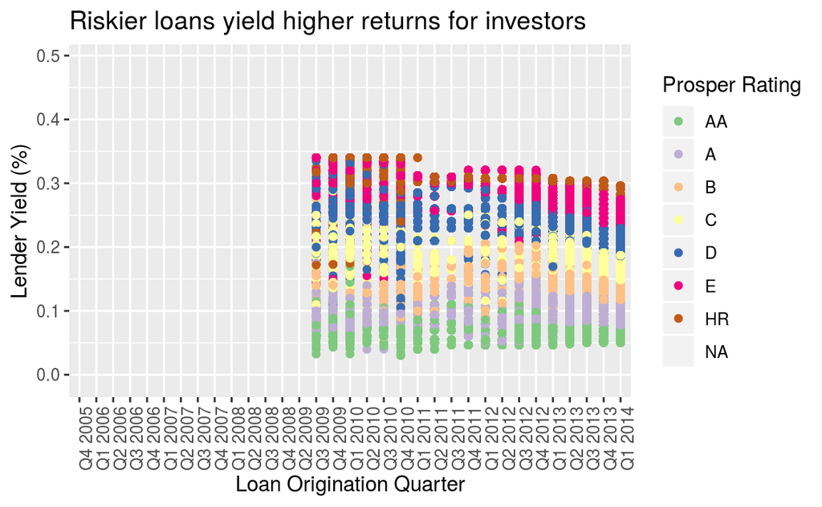

### Description Three

This clearly shows the post-2009 restructuring of lending rules. In 2009, the yields have a noisy pattern. As time progresses to 2014, the pattern becomes much more organized. Riskier loans tend to lead to higher yields. ——

# Reflection

I was a bit disappointed in this analysis and found it challenging for a number of reasons. I think a subject-matter expert would have been able to make a more insightful analysis. Since I’m not an expert in p2p lending or finance, I really struggled to understand what variables from the original 81 I should look into. Even narrowing it down to 16 variables made for a challenging exploration. In the end, I simply revealed some of the history behind the company and helped show why the SEC forced them to reorganize.

With a bit more time to research credit rating, I could possibly show more insightful analysis showing why pre-2009 Prosper was forced by the SEC to register.

That being said, I was fairly satisfied with my process once I got the hang of it. And I can see useful application of this process and these techniques in my own work at a non-profit.

Sources: https://en.wikipedia.org/wiki/Charge-off)  
https://en.wikipedia.org/wiki/Prosper_Marketplace  
https://www.lendacademy.com/prosper-review/  
https://www.consumerfinance.gov/ask-cfpb/what-is-a-debt-to-income-ratio-why-is-the-43-debt-to-income-ratio-important-en-1791/